# Importaciones

## Series de tiempo

### Serie de tiempo de la gasolina Regular

En este caso utilizaremos la construccion de modelos ARIMA el cual consta de 4 pasos, 1. Indentificacion 2. Estimacion 3. Validacion 4. Prediccion

#### Identificacion

```r
#Series de tiempo


library(forecast)
library(tseries)
library(fUnitRoots)
library(ggfortify)

importacion <- read_excel("importacion.xlsx")

regular<-importacion[c('Fecha','Gasolina regular')]
diesel<-importacion[c('Fecha','Diesel alto azufre')]
super<-importacion[c('Fecha','Gasolina superior')]

regular_ts <- ts( regular$`Gasolina regular`, start = c(2001,1),frequency = 12)

#Inicio de la serie de tiempo
start(regular_ts)
```

```
## [1] 2001    1
```

```r
#Final de la serie de tiempo
end(regular_ts)
```

```
## [1] 2022    5
```

```r
#Frecuencia de la serie
frequency(regular_ts)
```

```
## [1] 12
```

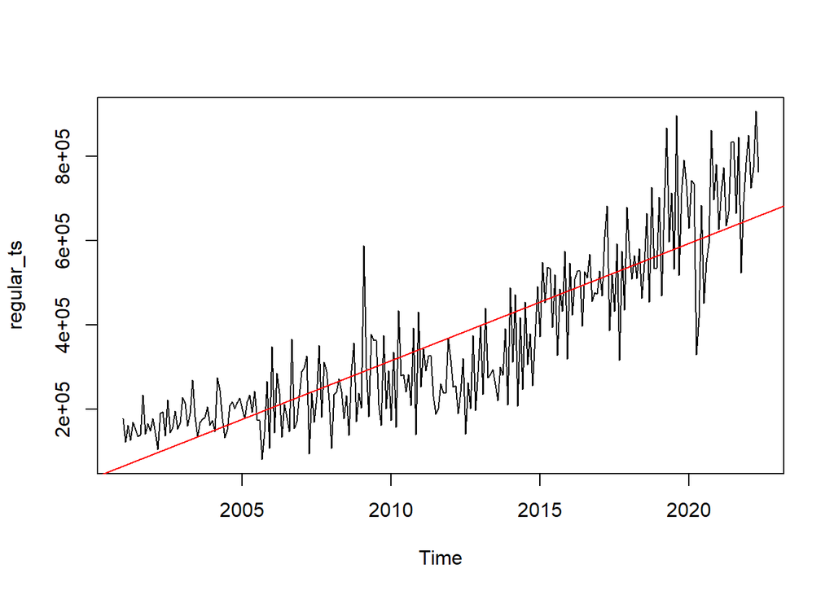

```r
#Grafica generada
plot(regular_ts)
abline(reg=lm(regular_ts~time(regular_ts)), col=c("red"))
```

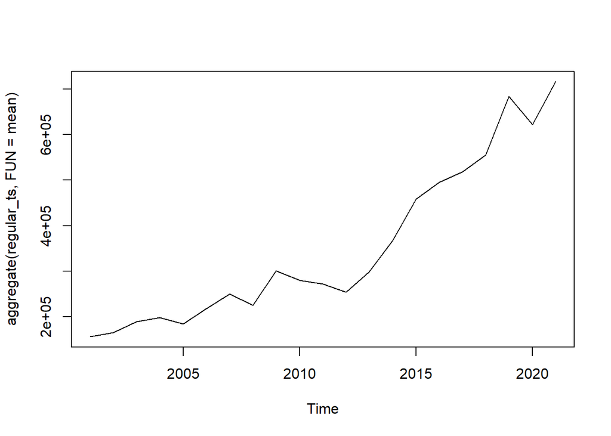

```r
plot(aggregate(regular_ts,FUN=mean))
```

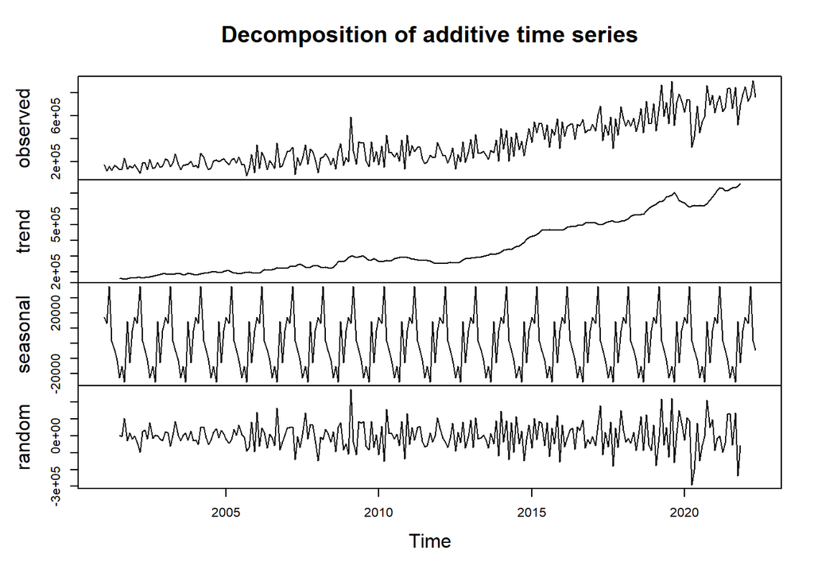

```r
dec.Regular<-decompose(regular_ts)
plot(dec.Regular)
```

Podemos observar una serie con tendencia a aumentar, que no es estacionaria en varianza, y además tiene estacionalidad.

#### Estimacion

Cómo no es estacionaria en varianza le haremos una transformación logaritmica para hacerla constante en varianza.Lo haremos con la serie de entrenamiento que es la que nos ayudará a predecir

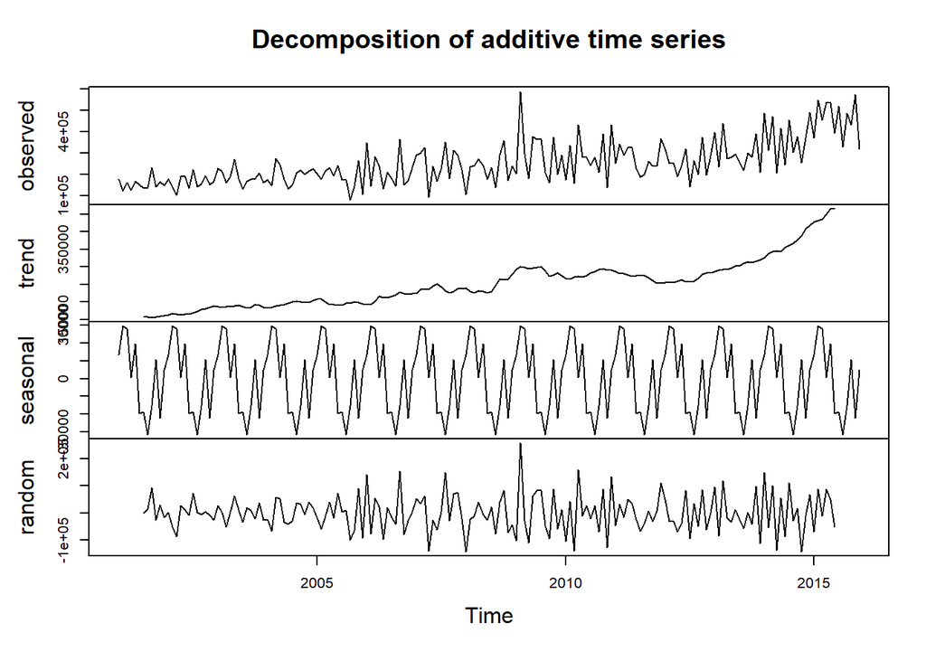

```r
train <- head(regular_ts, round(length(regular_ts) * 0.7))
h <- length(regular_ts) - length(train)
test <- tail(regular_ts, h)

#Aplicaremos una transformación logarítmica
logRegular <- log(train)
plot(decompose(train))
```

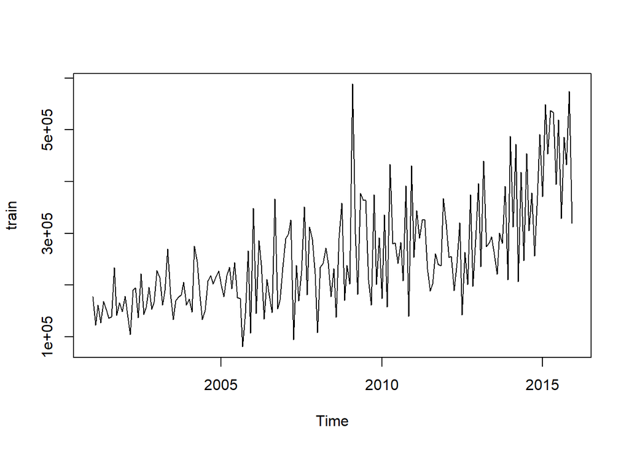

```r
#Ver el gráfico de la serie
plot(train)
```

```r
#Para saber si hay raíces unitarias
adfTest(train)
```

```
##
## Title:
##  Augmented Dickey-Fuller Test
##
## Test Results:
##   PARAMETER:
##     Lag Order: 1
##   STATISTIC:
##     Dickey-Fuller: -0.8286
##   P VALUE:
##     0.3507
##
## Description:
##  Mon Aug 08 23:39:53 2022 by user: xavih
```

```r
unitrootTest(train)
```

```
##
## Title:
##  Augmented Dickey-Fuller Test
##
## Test Results:
##   PARAMETER:
##     Lag Order: 1
##   STATISTIC:
##     DF: -0.8286
##   P VALUE:
##     t: 0.3558
##     n: 0.5026
##
## Description:
##  Mon Aug 08 23:39:53 2022 by user: xavih
```

```r
adfTest(diff(train))
```

```
##
## Title:
##  Augmented Dickey-Fuller Test
##
## Test Results:
##   PARAMETER:
##     Lag Order: 1
##   STATISTIC:
##     Dickey-Fuller: -15.6588
##   P VALUE:
##     0.01
##
## Description:
##  Mon Aug 08 23:39:53 2022 by user: xavih
```

```r
unitrootTest(diff(train))
```

```
##
## Title:
##  Augmented Dickey-Fuller Test
##
## Test Results:
##   PARAMETER:
##     Lag Order: 1
##   STATISTIC:
##     DF: -15.6588
##   P VALUE:
##     t: < 2.2e-16
##     n: 0.005102
##
## Description:
##  Mon Aug 08 23:39:53 2022 by user: xavih
```

Como se puede ver el valor de p ahora sí está por debajo de 0.05 por lo que se puede descartar la hipótesis nula de que existan raices unitarias. Es necesaria solo una diferenciación. Es decir d = 1. Trataremos de identificar los parámetros p y q usando los gráficos de autocorrelación y autocorrelación parcial.

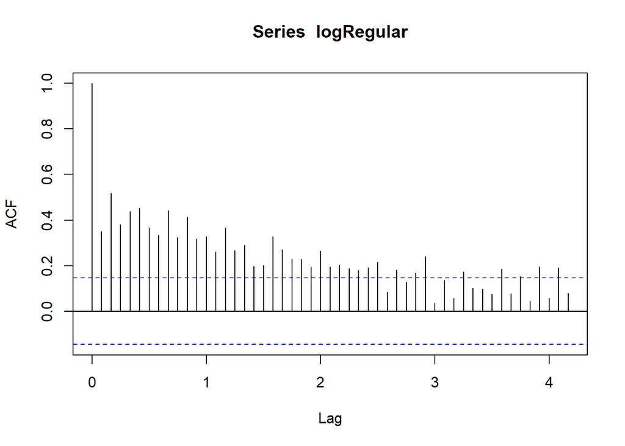

```r
#Gráfico de autocorrelación
acf(logRegular,50)
```

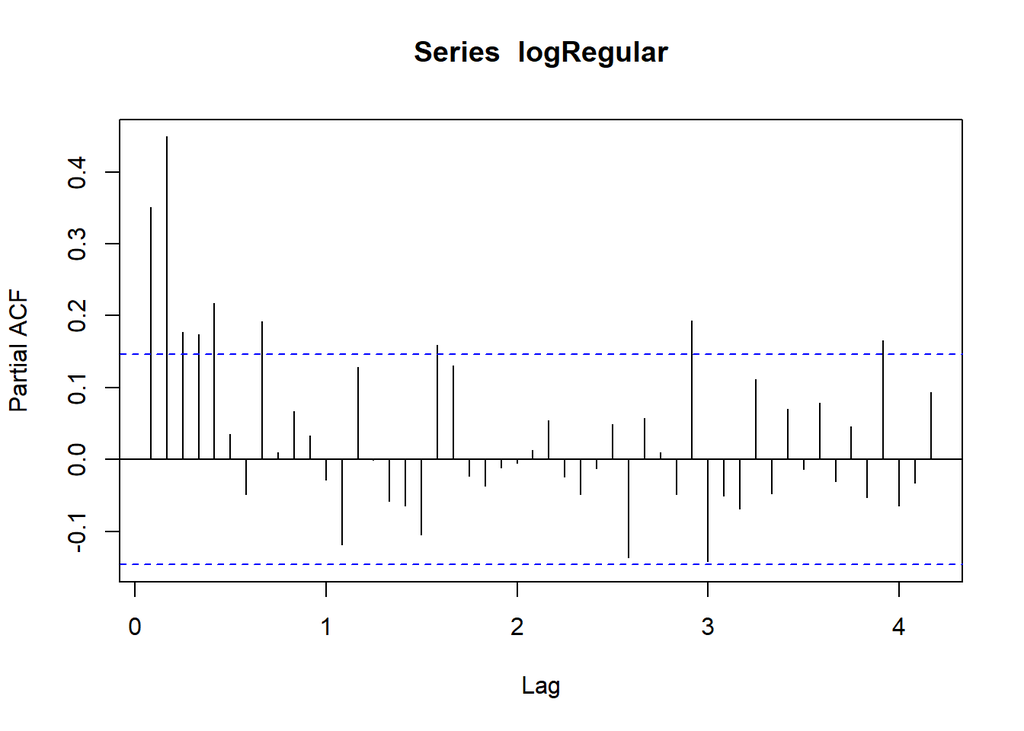

```r
pacf(logRegular,50)
```